# p8105_hw5_fj2269

Fangming Jin

2019/11/1

### Question 1

**1. import the data**

```r
set.seed(10)
iris_with_missing = iris %>%
  map_df(~replace(.x, sample(1:150, 20), NA)) %>%
  mutate(Species = as.character(Species))
iris_with_missing
```

```
## # A tibble: 150 x 5
##    Sepal.Length Sepal.Width Petal.Length Petal.Width Species
##           <dbl>       <dbl>        <dbl>       <dbl> <chr>
##  1          5.1         3.5          1.4         0.2 setosa
##  2          4.9         3            1.4         0.2 setosa
##  3          4.7         3.2          1.3         0.2 setosa
##  4          4.6         3.1          1.5        NA   setosa
##  5          5           3.6          1.4         0.2 setosa
##  6          5.4         3.9          1.7         0.4 setosa
##  7         NA           3.4          1.4         0.3 setosa
##  8          5           3.4          1.5         0.2 setosa
##  9          4.4         2.9          1.4         0.2 setosa
## 10          4.9         3.1         NA           0.1 setosa
## # ... with 140 more rows
```

**2. write the function and apply it to iris_with_missing

```r
replace_function = function(x){

  if (is.numeric(x)) {
    y = mean(x, na.rm = TRUE)
    x = replace_na(x, y)
  } else if (is.character(x)) {
    x = replace_na(x, "virginica")
  }
  x
}
iris_with_missing = map_df(iris_with_missing, replace_function)
iris_with_missing
```

```
## # A tibble: 150 x 5
##    Sepal.Length Sepal.Width Petal.Length Petal.Width Species
##           <dbl>       <dbl>        <dbl>       <dbl> <chr>
##  1         5.1          3.5         1.4         0.2  setosa
##  2         4.9          3           1.4         0.2  setosa
##  3         4.7          3.2         1.3         0.2  setosa
##  4         4.6          3.1         1.5         1.19 setosa
##  5         5            3.6         1.4         0.2  setosa
##  6         5.4          3.9         1.7         0.4  setosa
##  7         5.82         3.4         1.4         0.3  setosa
##  8         5            3.4         1.5         0.2  setosa
##  9         4.4          2.9         1.4         0.2  setosa
## 10         4.9          3.1         3.77        0.1  setosa
## # ... with 140 more rows
```

### Question 2

**1. tidy the data**

```r
longitudinal = tibble(name = list.files('./Q2/hw5_data/data')) %>%
  mutate(result = map(.x = str_c("./Q2/hw5_data/data/",name), ~read.csv(file = .x))) %>%
  janitor::clean_names() %>%
  separate(name, c("arm", "ID"), sep = "([\\_\\.])") %>%
  mutate(arm = recode(arm, "con"="control","exp"="experimental")) %>%
  mutate(result = map(result, as.numeric())) %>%
  drop_na()
longitudinal
```

```
## # A tibble: 20 x 3
##    arm          ID    result
##    <chr>        <chr> <list>
##  1 control      01    <df[,8] [1 x 8]>
##  2 control      02    <df[,8] [1 x 8]>
##  3 control      03    <df[,8] [1 x 8]>
##  4 control      04    <df[,8] [1 x 8]>
##  5 control      05    <df[,8] [1 x 8]>
##  6 control      06    <df[,8] [1 x 8]>
##  7 control      07    <df[,8] [1 x 8]>
##  8 control      08    <df[,8] [1 x 8]>
##  9 control      09    <df[,8] [1 x 8]>
## 10 control      10    <df[,8] [1 x 8]>
## 11 experimental 01    <df[,8] [1 x 8]>
## 12 experimental 02    <df[,8] [1 x 8]>
## 13 experimental 03    <df[,8] [1 x 8]>
## 14 experimental 04    <df[,8] [1 x 8]>
## 15 experimental 05    <df[,8] [1 x 8]>
## 16 experimental 06    <df[,8] [1 x 8]>
## 17 experimental 07    <df[,8] [1 x 8]>
## 18 experimental 08    <df[,8] [1 x 8]>
## 19 experimental 09    <df[,8] [1 x 8]>
## 20 experimental 10    <df[,8] [1 x 8]>
```

```r
longitudinal %>% unnest %>% unnest
```

```
## # A tibble: 20 x 10
##    arm        ID    week_1 week_2 week_3 week_4 week_5 week_6 week_7 week_8
##    <chr>      <chr>  <dbl>  <dbl>  <dbl>  <dbl>  <dbl>  <dbl>  <dbl>  <dbl>
##  1 control    01      0.2  -1.31    0.66   1.96   0.23   1.09   0.05   1.94
##  2 control    02      1.13 -0.88    1.07   0.17  -0.83  -0.31   1.58   0.44
##  3 control    03      1.77  3.11    2.22   3.26   3.31   0.89   1.88   1.01
##  4 control    04      1.04  3.66    1.22   2.33   1.47   2.7    1.87   1.66
##  5 control    05      0.47 -0.580  -0.09  -1.37  -0.32  -2.17   0.45   0.48
##  6 control    06      2.37  2.5     1.59  -0.16   2.08   3.07   0.78   2.35
##  7 control    07      0.03  1.21    1.13   0.64   0.49  -0.12  -0.07   0.46
##  8 control    08     -0.08  1.42    0.09   0.36   1.18  -1.16   0.33  -0.44
##  9 control    09      0.08  1.24    1.44   0.41   0.95   2.75   0.3    0.03
## 10 control    10      2.14  1.15    2.52   3.44   4.26   0.97   2.73  -0.53
## 11 experimen~ 01      3.05  3.67    4.84   5.8    6.33   5.46   6.38   5.91
## 12 experimen~ 02     -0.84  2.63    1.64   2.58   1.24   2.32   3.11   3.78
## 13 experimen~ 03      2.15  2.08    1.82   2.84   3.36   3.61   3.37   3.74
## 14 experimen~ 04     -0.62  2.54    3.78   2.73   4.49   5.82   6      6.49
## 15 experimen~ 05      0.7   3.33    5.34   5.57   6.9    6.66   6.24   6.95
## 16 experimen~ 06      3.73  4.08    5.4    6.41   4.87   6.09   7.66   5.83
## 17 experimen~ 07      1.18  2.35    1.23   1.17   2.02   1.61   3.13   4.88
## 18 experimen~ 08      1.37  1.43    1.84   3.6    3.8    4.72   4.68   5.7
## 19 experimen~ 09     -0.4   1.08    2.66   2.7    2.8    2.64   3.51   3.27
## 20 experimen~ 10      1.09  2.8     2.8    4.3    2.25   6.57   6.09   4.64
```

**2. make spaghetti plot**

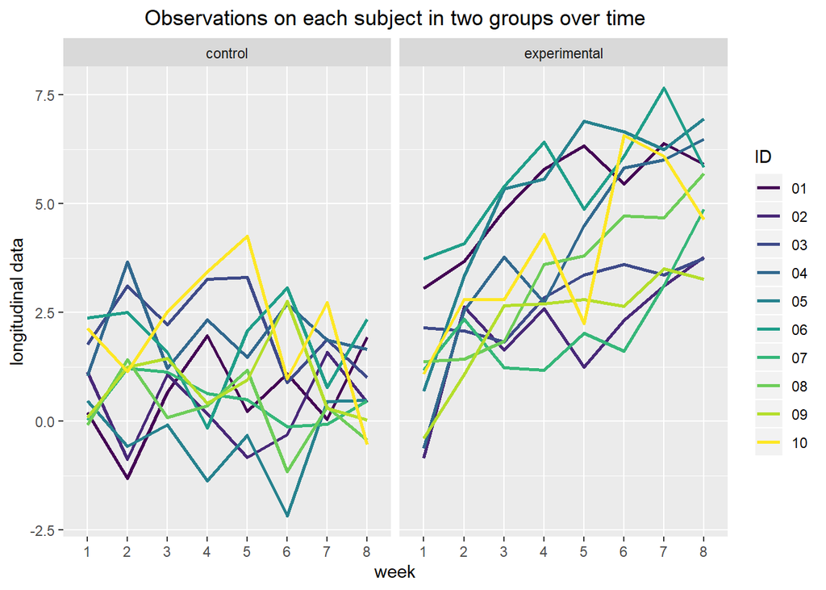

```r
plot_spag = longitudinal %>%
  unnest %>% unnest %>%
  pivot_longer(
    week_1:week_8,
    names_to = "week",
    values_to ="data",
    names_prefix = "week_") %>%
  ggplot(aes(x = week, y = data, group = ID, color = ID)) +
    geom_line(size=1) +
    facet_grid(~arm) +
    labs(title = "Observations on each subject in two groups over time", y = "longitudinal data") +
    theme(plot.title = element_text(hjust = 0.5), legend.position = "right") +
    viridis::scale_color_viridis(discrete = TRUE)
plot_spag
```

The longitudinal data in control group does not change over time, and longitudinal data in exprimental group increases significantly as time passes. In first two weeks the longitudinal data in experimental group is close to that in control group. But as time pass, the longitudinal data in experimental group is significanty higher than that in control group.

### Question 3

**1.simulation**

```r
set.seed(12)
sim_regression = function(n = 30, beta0 = 2, beta1) {

  sim_data = tibble(
    x = rnorm(n, mean = 0, sd = 1),
    y = beta0 + beta1 * x + rnorm(n, 0, sqrt(50))
  )

  ls_fit = lm(y ~ x, data = sim_data)

  tibble(
    beta1_hat = coef(ls_fit)[2],
    beta1_p_value = pull(broom::tidy(ls_fit),p.value)[[2]]
  )
}
output =
  tibble(beta1_true = c(0:6)) %>%
  mutate(
    output_lists = map(.x = beta1_true, ~rerun(10000, sim_regression(beta1 = .x))),
    estimate_dfs = map(output_lists, bind_rows)) %>%
  select(-output_lists) %>%
  unnest(estimate_dfs)
```

**2.The relationship between effect size and power**

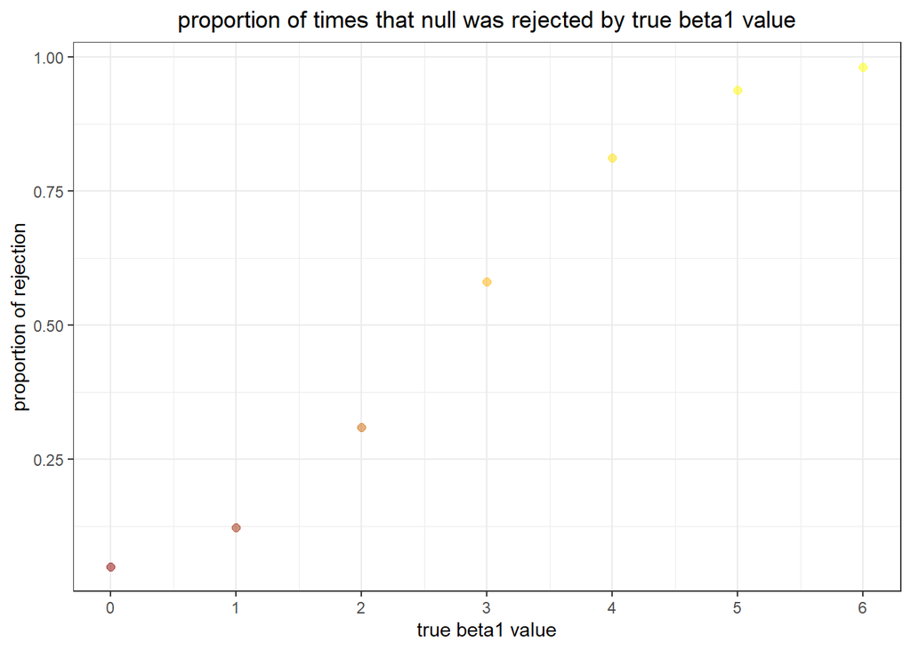

```r
output %>%
  filter(beta1_p_value < 0.05) %>%
  group_by(beta1_true) %>%
  summarize(
    prop_reject = n()/10000
  ) %>%
  ggplot(aes(x = beta1_true, prop_reject, color = prop_reject)) +
    theme_bw() +
    geom_point(size = 2, alpha = 0.5) +
    scale_color_gradientn(colors=c("darkred", "orange", "yellow")) +
    labs(title = "proportion of times that null was rejected by true beta1 value", x="true beta1 value", y="proportion of rejection") +
    theme(plot.title = element_text(hjust = 0.5),legend.position = "none") +
    scale_x_continuous(
    breaks = c(0,1,2,3,4,5,6),
    labels = c(0,1,2,3,4,5,6))
```

We already know β1 in H0 and H1:in H0, β1=0， in H1, β1 is equal to true beta that we have already known(β1 = {0,1,2,3,4,5,6}).

Effect size is calculated by taking the difference between β in H0 and H1 and dividing it by sd. In this test, sd is equal to error term’s sd, σ.

Based on graph above, as true beta increases, effect size increases, proportion of rejection increases. This means the proportion of rejecting false null hypothesis increases as effect size increases, power increases as effect size increases.

**3.**

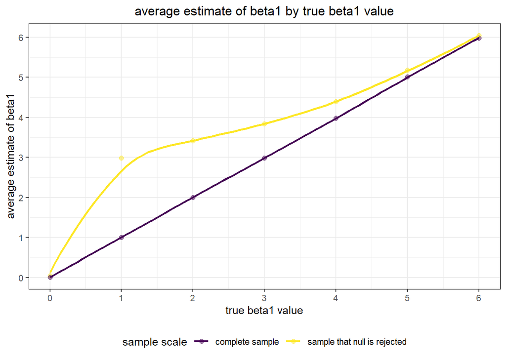

```r
mean_sum = output %>%
  group_by(beta1_true) %>%
  summarize(
    mean_beta1 = mean(beta1_hat)
  ) %>%
  mutate(group = rep("complete sample"))
mean_reject = output %>%
  filter(beta1_p_value < 0.05) %>%
  group_by(beta1_true) %>%
  summarize(
    mean_beta1 = mean(beta1_hat)
  ) %>%
  mutate(group = rep("sample that null is rejected"))
mean_beta1 = bind_rows(mean_reject, mean_sum)
ggplot(mean_beta1, aes(x = beta1_true, y = mean_beta1, group = group, color = group)) +
  theme_bw() +
  geom_point(size = 2, alpha = 0.5) +
  geom_smooth(se = FALSE) +
  labs(title = "average estimate of beta1 by true beta1 value", x="true beta1 value", y="average estimate of beta1") +
  viridis::scale_color_viridis(
    name = "sample scale",
    discrete = TRUE
  ) +
  theme(plot.title = element_text(hjust = 0.5),legend.position = "bottom") +
  scale_x_continuous(
    breaks = c(0,1,2,3,4,5,6),
    labels = c(0,1,2,3,4,5,6)) +
  scale_y_continuous(
    breaks = c(0,1,2,3,4,5,6),
    labels = c(0,1,2,3,4,5,6))
```

According to graph above, the sample average of estimated β1 across tests for complete sample is close to the true value of β1 no matter how much true β1 is. But the sample average of estimated β1 across tests for which the null is rejected does not equal to the true value of β1 when β1 is 1, 2 and 3. The value of estimated β1 for sample that null is rejected is close to value of true β1 when β1 is small(β1 = 0) or β1 is big(β1 = 4, 5 and 6)